# NMDS

### Habitat drivers of community composition

**Individual habitat drivers of small mammal communities:**

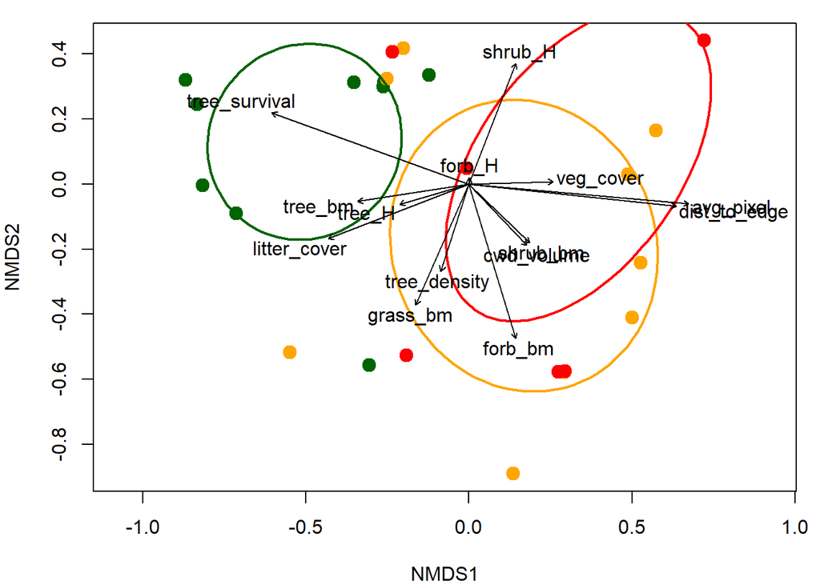

- The NMDS plot shows variation in community composition of small mammals, standardized by trapping effort. NMDS was performed on on Bray-Curtis distances in three dimensions (stress = 0.09). Each circle represents a site, with the standard deviation of the centroids for each fire severity represented as color-coded ellipses (n = 9 for each). Arrows represent the relative contributions of several possible habitat variables. Community composition was significantly different between fire severity treatments (Adonis F(2,24) = 4.39, R<sup>2</sup> = 0.268, p = 0.003). Post-hoc analysis by pairwise Adonis showed that community composition in unburned sites and high severity sites was significantly different (pairwise p = 0.006).
- Appears to be fewer sites because some of them exactly overlap
- Habitat variables:
  - *avg_severity* - mean severity of pixels within the site, based on MTBS fire severity data (0-3 = unburned-high severity)
  - *dist_to_edge* - distance from the site center to the burn boundary (negative for sites outside the burn boundary)
  - *tree_bm* - density of adult tree biomass (live or dead) (kg/m<sup>2</sup>)
  - *shrub_bm* - density of live shrub biomass (kg/m<sup>2</sup>)
  - *grass_bm* - density of live grass biomass (kg/m<sup>2</sup>)
  - *forb_bm* - density of live forb biomass (kg/m<sup>2</sup>)
  - *tree_density* - density of trees (live or dead) (indv/m<sup>2</sup>)
  - *tree_survival* - proportion of live trees (%)
  - *veg_cover* - total proportion of vegetation cover (all species/life-forms - can sum to >100) (both transects) (%)
  - *litter_cover* - proportion of litter cover (%)
  - *cwd_volume* - density of coarse woody debris volume (m<sup>3</sup>/m<sup>2</sup>)
  - *tree_H* - Shannon diversity of adult trees
  - *shrub_H* - Shannon diversity of adult trees
  - *forb_H* - Shannon diversity of adult trees

**NMDS plot with PCA scores:**

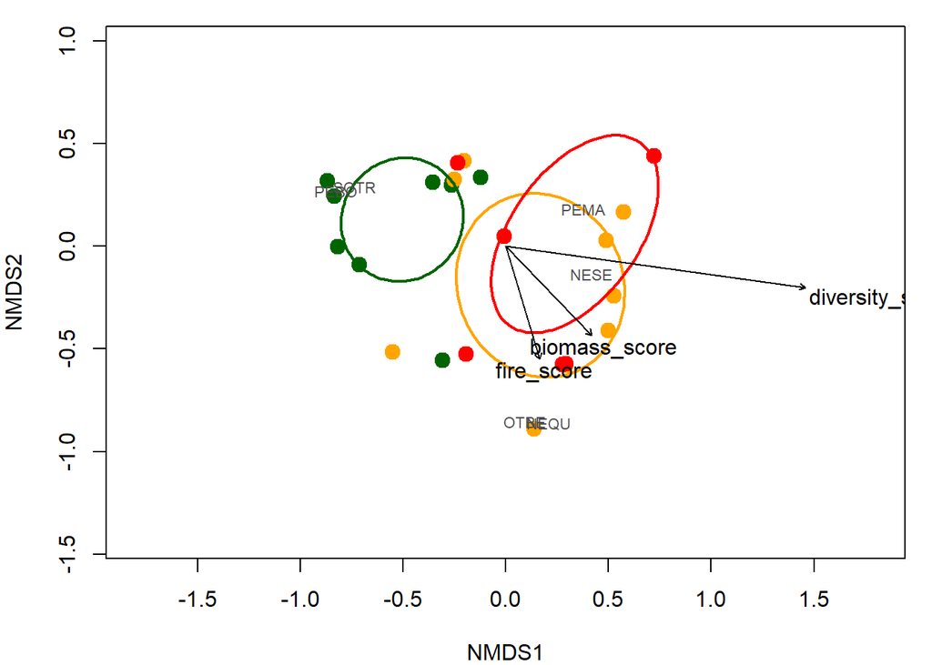

- *fire_score* = avg_severity + dist_to_edge + tree_survival
- *biomass_score* = tree_bm + shrub_bm + grass_bm + forb_bm
- *diversity_score* = tree_H + shrub_H + forb_H

**NMDS plot with best variables from mvGLM:**

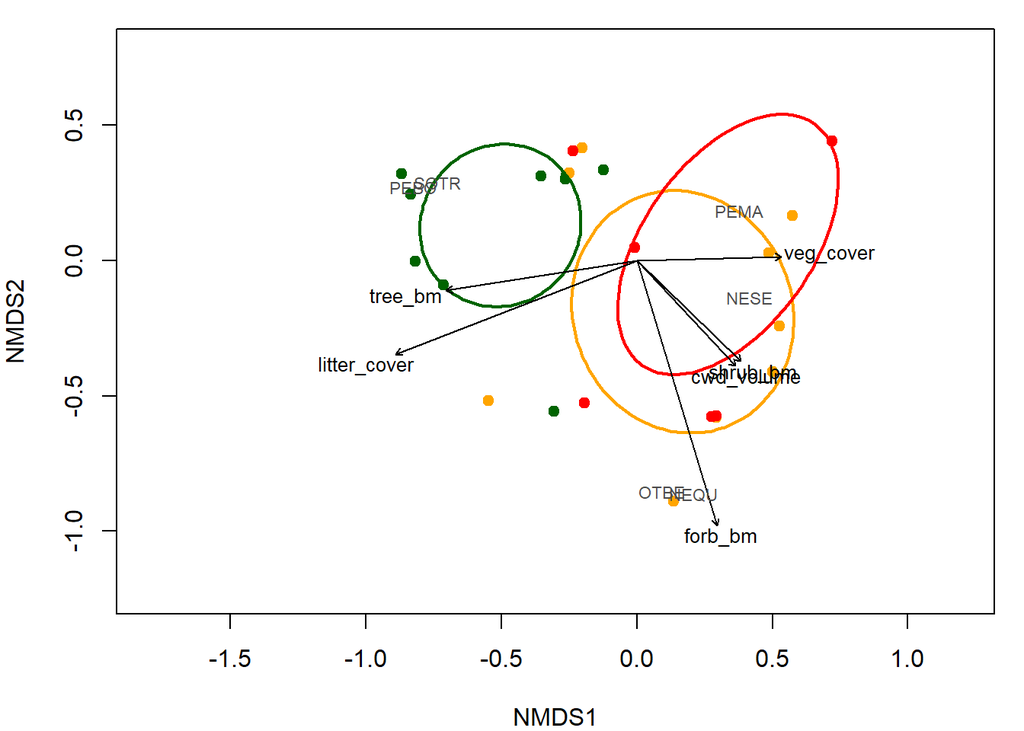

**Clean NMDS plots with ggplot:**

*NMDS in 3 dimensions*

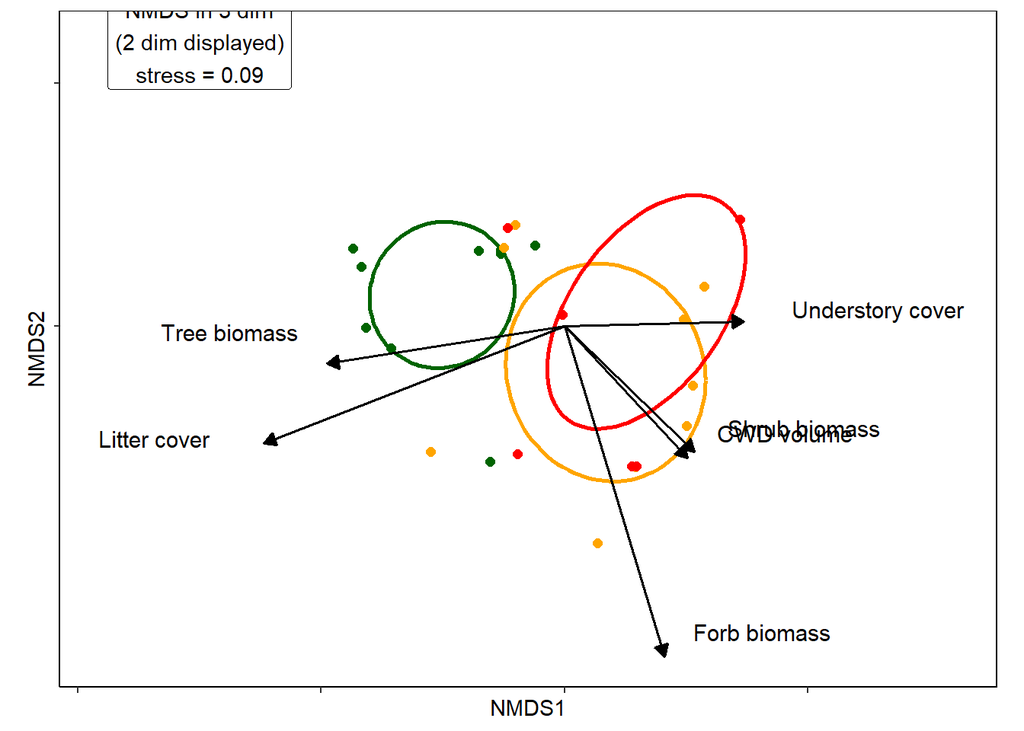

*NMDS in 2 dimensions*

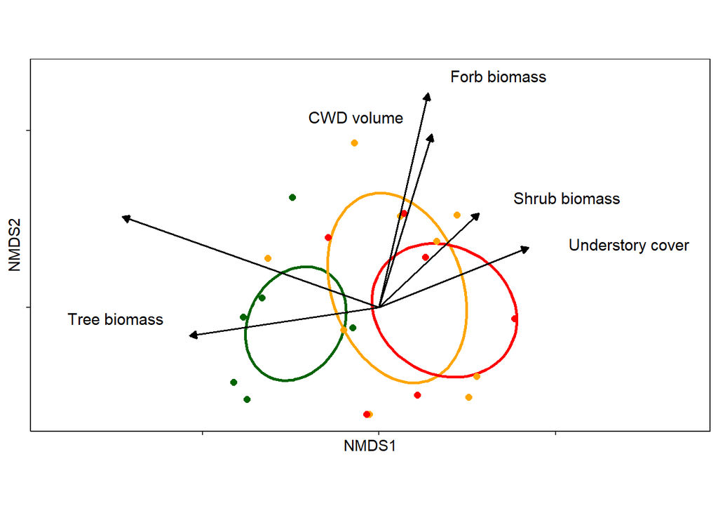